# An example DFO performance plot

A prototype MSE performance evaluation

T. Carruthers

2018-04-26

# 1 About this document

This is a prototype of an automatic report that describes the results of a demonstration MSE analysis for the Canadian Department of Fisheries and Oceans.

# 2 Performance table

A generic performance table is produced that provides the probability of stock status in the critical, cautious and healthy zones (delineated by 40% and 80% of BMSY). Also provided are the probability of overfishing and the yield relative to FMSY fishing. These performance metrics are provided for the first and last 10 years of the MSE projection in addition to the average annual variability in yield over all projected years and the probability of rebuilding to over BMSY after two mean generation times.

Below the table are a set of the threshold levels for satisficing. Only those MPs that simultaneously meet all thresholds are satisficed (as indicated by green font for the MP name). MPs are presented in descending order of yield over the final 10 years.

| MP | MP_Type | First 10 years of MSE projection Crit_S | First 10 years of MSE projection Caut_S | First 10 years of MSE projection Health_S | First 10 years of MSE projection OvFish_S | First 10 years of MSE projection Yield_S | Last 10 years of MSE projection Crit | Last 10 years of MSE projection Caut | Last 10 years of MSE projection Health | Last 10 years of MSE projection OvFish | Last 10 years of MSE projection Yield | AAVY | Reb |
| --- | --- | --- | --- | --- | --- | --- | --- | --- | --- | --- | --- | --- | --- |
| FMSYref | TAC | 2 | 22 | 75 | 59 | 136 | 5 | 36 | 58 | 58 | 98 | 4 | 38 |
| MRreal | MPA | 7 | 14 | 79 | 27 | 94 | 13 | 11 | 76 | 24 | 75 | 25 | 69 |
| curE | TAE | 10 | 14 | 76 | 31 | 97 | 17 | 8 | 74 | 26 | 74 | 25 | 65 |
| matlenlim | SzLim | 2 | 9 | 89 | 5 | 55 | 2 | 2 | 96 | 4 | 64 | 25 | 92 |
| DCAC | TAC | 3 | 8 | 89 | 7 | 75 | 20 | 1 | 79 | 21 | 51 | 3 | 90 |
| AvC | TAC | 11 | 11 | 78 | 24 | 97 | 33 | 3 | 64 | 38 | 46 | 9 | 69 |

| MP | MP_Type | Thresholds Crit_S | Thresholds Caut_S | Thresholds Health_S | Thresholds OvFish_S | Thresholds Yield_S | Thresholds Crit | Thresholds Caut | Thresholds Health | Thresholds OvFish | Thresholds Yield | Thresholds AAVY | Thresholds Reb |
| --- | --- | --- | --- | --- | --- | --- | --- | --- | --- | --- | --- | --- | --- |
| NANANAN | NA | 30 | 50 | 40 | 60 | 50 | 20 | 40 | 50 | 60 | 50 | 30 | 50 |

- Crit_S is the probability of being in the critical zone in the first 10 projected years
- Caut_S is the probability of being in the cautious zone in the first 10 projected years
- Health_S is the probability of being in the healthy zone in the first 10 projected years
- OvFish_S is the probability of overfishing in the first 10 projected years
- Yield_S is the mean yield relative to FMSY management over the first 10 projected years
- Crit is the probability of being in the critical zone in the last 10 projected years
- Caut is the probability of being in the cautious zone in the last 10 projected years
- Health is the probability of being in the healthy zone in the last 10 projected years
- OvFish is the probability of overfishing in the last 10 projected years
- Yield is the mean yield relative to FMSY management over the last 10 projected years
- AAVY is the average annual variability in yield over the whole projection phrased as a CV percentage
- Reb is the probability the stock rebuilt to over BMSY in two generation times

# 3 Worm plots

The quantile worm plots show the central 90% probability interval (transparent blue region) and 50% probability intervals (blue shaded area) of future projections and the mean among all simulations (solid white line).

Superimposed on each plot are two individual simulations (the solid and dashed blue lines). For each management procedure (panel columns) the biomass relative to BMSY and the yield relative to FMSY yield (Rel. Yd.) are plotted.

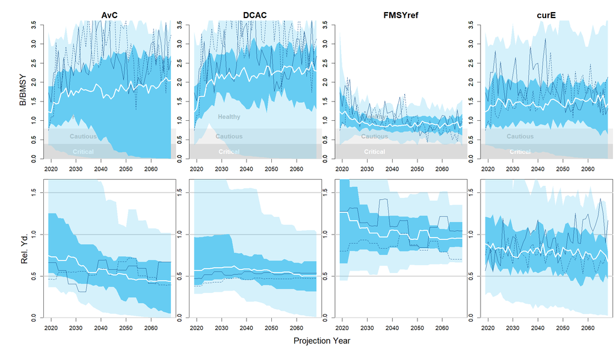

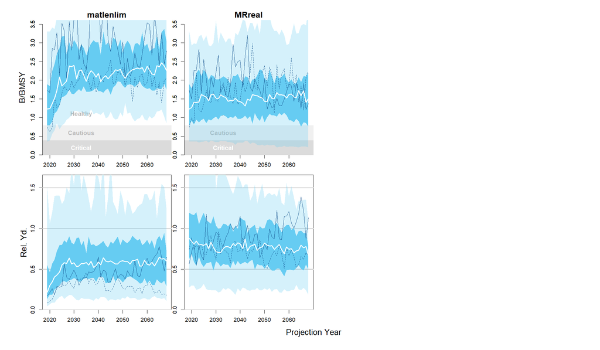

# 4 Spider plots

Spider plots offer a way of presenting trade-offs among multiple performance metrics. These are however generally difficult to read with greater than 5 performance metrics (spokes) and more than 3 management procedures. Here is an example showing the tradeoff among short-term yield (yield relative to FMSY over first 10 projected years), long term yield (yield relative to FMSY over final 10 projected years) and probability of biomass in the healthy zone (greater than 80% BMSY) for the three MPs with the highest long term yields.

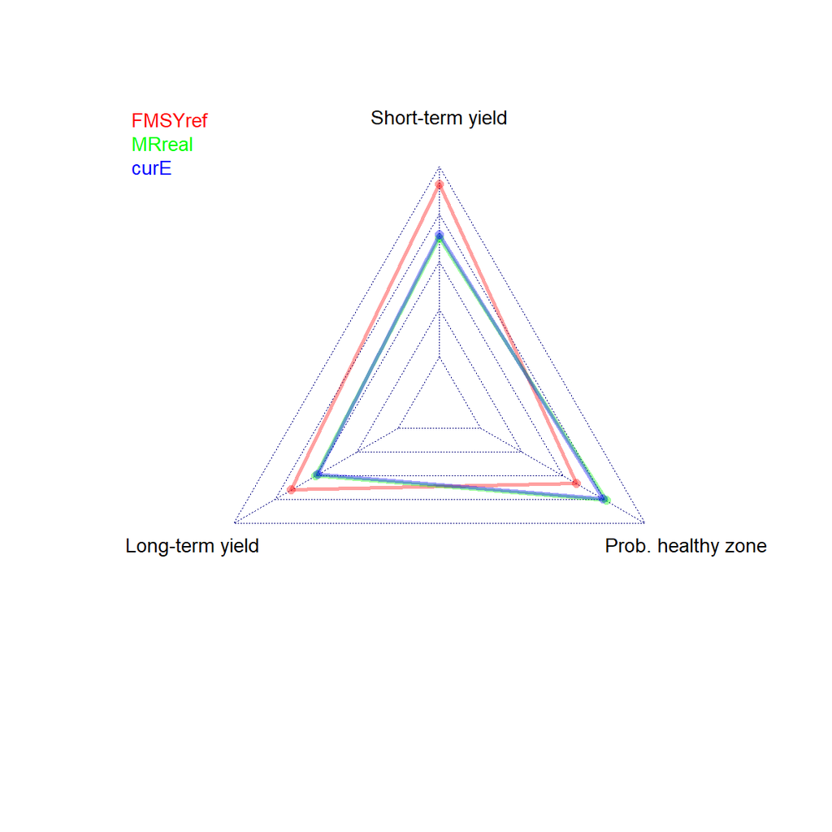

# 5 Bar plot

The bar plots (‘Zeh plots’) are similar to the quantile plot above and show the biomass relative to BMSY over projected time periord. Each panel represents a different 10 year period of the MSE projection. The bars present the 90% and the 50% (solid line) probability intervals. The dots are the median biomass / BMSY.

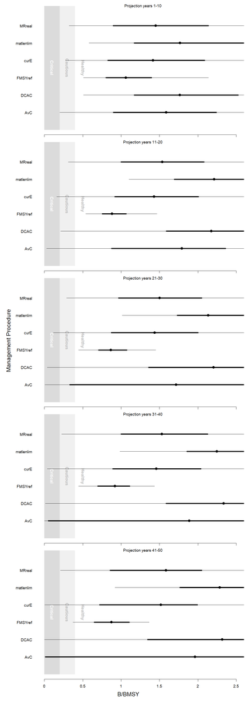

# 6 Tradeoff plot

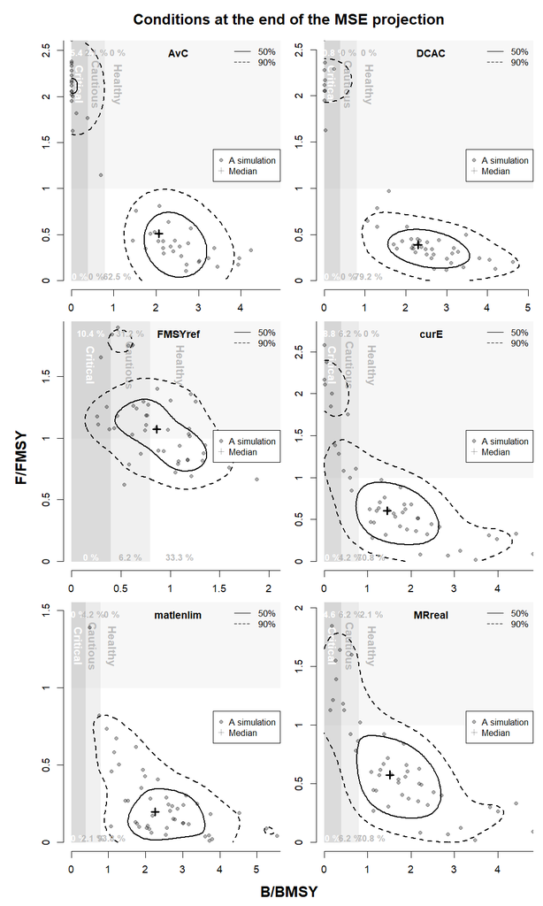

# 7 Version Notes

This report is subject to ongoing testing. If you find a bug or a problem please send a report to t.carruthers@oceans.ubc.ca so that it can be fixed or report an issue at www.github.com/DLMtool/DLMtool/issues.